# Predicting Wine Quality in Reds and Whites

Darion Lawson

# Introduction

This analysis takes a look at physicochemical analysis data collected form red wine and white wine samples plus quality ratings assigned to each sample by wine experts. A random forest model is built to predict quality rating from the chemical properties of wine.

Data was obtained from [UCI Data Repository](http://archive.ics.uci.edu/ml/datasets/Wine+Quality) and was contributed by Paulo Cortez, University of Minho, Guimaraes, Portugal.

# Import Packages

```r
source("C:/_stuff/r.code.snippets/all.imports.R")
```

# Load Data

There are two datasets one each for the red and white variants of the Portuguese “Vinho Verde” wine. The variables are chemical characterstics of the wines. The response is the Quality rating assigned by wine experts (the median of at least 3 evaluations) expert graded the wine quality. Ratings are 0 (very bad) and 10 (very excellent).

```r
wine.r <- read.csv("C:/_data/wine.quality/winequality-red.csv", sep=";")
wine.w <- read.csv("C:/_data/wine.quality/winequality-white.csv", sep=";")

wine.r$quality <- as.factor(wine.r$quality)
wine.w$quality <- as.factor(wine.w$quality)

str(wine.w);str(wine.r)
```

```
## 'data.frame':    4898 obs. of  12 variables:
##  $ fixed.acidity       : num  7 6.3 8.1 7.2 7.2 8.1 6.2 7 6.3 8.1 ...
##  $ volatile.acidity    : num  0.27 0.3 0.28 0.23 0.23 0.28 0.32 0.27 0.3 0.22 ...
##  $ citric.acid         : num  0.36 0.34 0.4 0.32 0.32 0.4 0.16 0.36 0.34 0.43 ...
##  $ residual.sugar      : num  20.7 1.6 6.9 8.5 8.5 6.9 7 20.7 1.6 1.5 ...
##  $ chlorides           : num  0.045 0.049 0.05 0.058 0.058 0.05 0.045 0.045 0.049 0.044 ...
##  $ free.sulfur.dioxide : num  45 14 30 47 47 30 30 45 14 28 ...
##  $ total.sulfur.dioxide: num  170 132 97 186 186 97 136 170 132 129 ...
##  $ density             : num  1.001 0.994 0.995 0.996 0.996 ...
##  $ pH                  : num  3 3.3 3.26 3.19 3.19 3.26 3.18 3 3.3 3.22 ...
##  $ sulphates           : num  0.45 0.49 0.44 0.4 0.4 0.44 0.47 0.45 0.49 0.45 ...
##  $ alcohol             : num  8.8 9.5 10.1 9.9 9.9 10.1 9.6 8.8 9.5 11 ...
##  $ quality             : Factor w/ 7 levels "3","4","5","6",..: 4 4 4 4 4 4 4 4 4 4 ...
```

```
## 'data.frame':    1599 obs. of  12 variables:
##  $ fixed.acidity       : num  7.4 7.8 7.8 11.2 7.4 7.4 7.9 7.3 7.8 7.5 ...
##  $ volatile.acidity    : num  0.7 0.88 0.76 0.28 0.7 0.66 0.6 0.65 0.58 0.5 ...
##  $ citric.acid         : num  0 0 0.04 0.56 0 0 0.06 0 0.02 0.36 ...
##  $ residual.sugar      : num  1.9 2.6 2.3 1.9 1.9 1.8 1.6 1.2 2 6.1 ...
##  $ chlorides           : num  0.076 0.098 0.092 0.075 0.076 0.075 0.069 0.065 0.073 0.071 ...
##  $ free.sulfur.dioxide : num  11 25 15 17 11 13 15 15 9 17 ...
##  $ total.sulfur.dioxide: num  34 67 54 60 34 40 59 21 18 102 ...
##  $ density             : num  0.998 0.997 0.997 0.998 0.998 ...
##  $ pH                  : num  3.51 3.2 3.26 3.16 3.51 3.51 3.3 3.39 3.36 3.35 ...
##  $ sulphates           : num  0.56 0.68 0.65 0.58 0.56 0.56 0.46 0.47 0.57 0.8 ...
##  $ alcohol             : num  9.4 9.8 9.8 9.8 9.4 9.4 9.4 10 9.5 10.5 ...
##  $ quality             : Factor w/ 6 levels "3","4","5","6",..: 3 3 3 4 3 3 3 5 5 3 ...
```

# Exploratory Data Analysis

Plot the individual variables against quality.

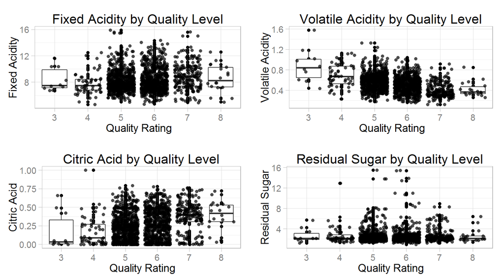

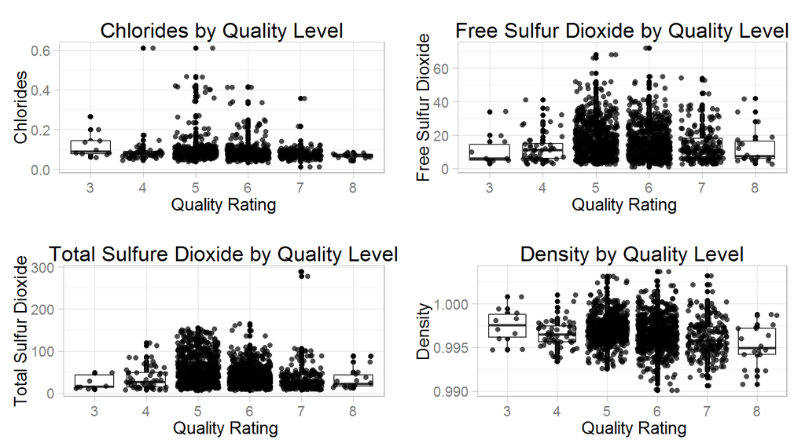

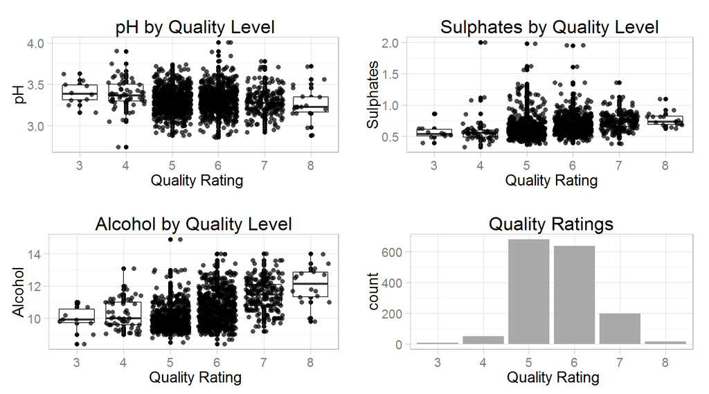

## Correlation Plots

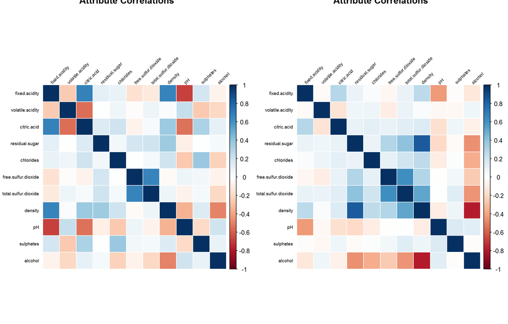

```r
library(corrplot)
cor.wine.r <- cor(wine.r[,-12])
cor.wine.w <- cor(wine.w[,-12])

par(mfrow=c(1,2))
corrplot(cor.wine.r, method = "color", type="full", order="original", tl.cex = 0.6,
         tl.col="black", tl.srt = 45, main="Attribute Correlations")

corrplot(cor.wine.w, method = "color", type="full", order="original", tl.cex = 0.6,
         tl.col="black", tl.srt = 45, main="Attribute Correlations")
```

## Pairs Plot with Additional Detail

The bottom left of the matrix contains scatter plots, the upper right of the matrix contains the correlation between the two attributes, and the diagonal contain the variable histogram.

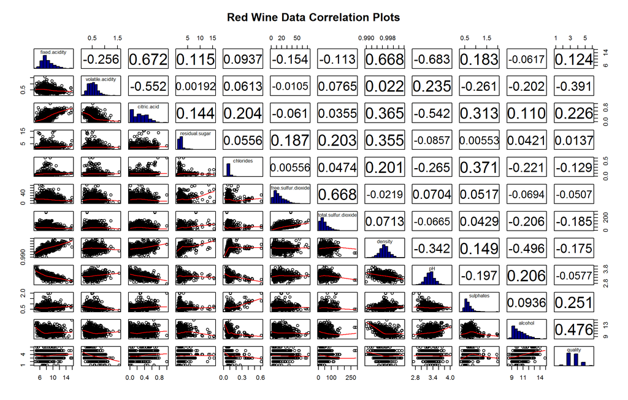

```r
source("C:/_stuff/r.code.snippets/pairs.panels.R")
par(mfrow=c(1,2))
pairs(wine.r,lower.panel=panel.smooth, upper.panel=panel.cor,diag.panel=panel.hist, main="Red Wine Data Correlation Plots")
```

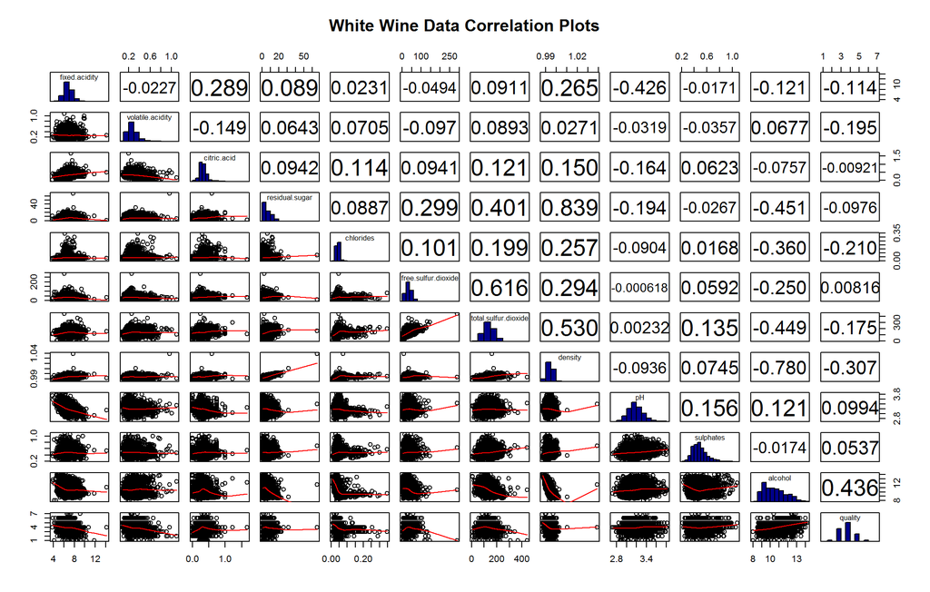

```r
pairs(wine.w,lower.panel=panel.smooth, upper.panel=panel.cor,diag.panel=panel.hist, main="White Wine Data Correlation Plots")
```

Variables with strong correlations.

In red wine, * fixed.acidity and density have a 0.668 correlation coefficient; both are commparably correlated to the response, quality * fixed.acidity and citric.acid have a 0.672 correlation coefficient; citric.acid is more strongly correlated to the response, quality. * fixed.acidity and pH have a -0.683 correlation coefficient; fixed.acidity is more strongly correlated to the response, quality. * free.sulfur.dioxide and total sulfur dioxide have a 0.668 correlation coefficient; while total.sulfur.dioxide is more strongly correlated to the response, quality.

After removing the correlated variables, prediction performance was not signnificantly improved, and in the case of white wine, was degraded slightly. All predictor variables will be kept.

Red Wine Error Rate - Random Forest model using cross validation

| . | Not Subset | Subset |
| --- | --- | --- |
| Not Scaled | 27.02% BEST | 27.7% |
| Scaled | 28.02% | 28.27% |

White Wine Error Rate - Random Forest model using cross validation

| . | Not Subset | Subset |
| --- | --- | --- |
| Not Scaled | 28.5% | 28.69% |
| Scaled | 28.07% BEST | 29.01% |

```r
# create temp data frames for analysis
wine.rs <- wine.r
wine.ws <- wine.w
```

# Separate into training and test data sets

Separated 2/3 of observations into training set, and 1/3 of observations into the test set.

```r
train.ids.rs <- sample(nrow(wine.rs),(nrow(wine.rs)/3)*2)
wine.rs.train <- wine.rs[train.ids.rs,]
wine.rs.test <- wine.rs[-train.ids.rs,]

train.ids.ws <- sample(nrow(wine.ws),(nrow(wine.ws)/3)*2)
wine.ws.train <- wine.ws[train.ids.ws,]
wine.ws.test <- wine.ws[-train.ids.ws,]
```

# Train the Models in Training Set

Build model for red wine quality predictions. Although the document [Manual–Setting Up, Using, And Understanding Random Forests V4.0](http://www.stat.berkeley.edu/~breiman/Using_random_forests_v4.0.pdf) indicates that cross-validation is not needed to get an unbiased estimate of the test set error, it was used as best practice when building models.

Build model to predict red wine quality rating.

```r
set.seed(10)
m.winers.cv <- train(quality~., data=wine.rs.train, method="rf",
                  trControl = trainControl(method = "cv"))
m.winers.cv$finalModel
```

```
##
## Call:
##  randomForest(x = x, y = y, mtry = param$mtry)
##                Type of random forest: classification
##                      Number of trees: 500
## No. of variables tried at each split: 2
##
##         OOB estimate of  error rate: 30.49%
## Confusion matrix:
##   3 4   5   6  7 8 class.error
## 3 0 0   7   0  0 0   1.0000000
## 4 0 0  24   7  0 0   1.0000000
## 5 1 0 346  87  4 0   0.2100457
## 6 0 1  86 323 21 0   0.2505800
## 7 0 0   6  70 72 0   0.5135135
## 8 0 0   0   8  3 0   1.0000000
```

Build model to predict white wine quality rating.

```r
set.seed(10)
m.winews.cv <- train(quality~., data=wine.ws.train, method="rf",
                    trControl = trainControl(method = "cv"))
m.winews.cv$finalModel
```

```
##
## Call:
##  randomForest(x = x, y = y, mtry = param$mtry)
##                Type of random forest: classification
##                      Number of trees: 500
## No. of variables tried at each split: 2
##
##         OOB estimate of  error rate: 33.11%
## Confusion matrix:
##   3  4   5    6   7  8 9 class.error
## 3 0  0   5   10   0  0 0   1.0000000
## 4 0 20  51   43   0  0 0   0.8245614
## 5 0  4 619  318   9  0 0   0.3484211
## 6 0  3 197 1206  77  0 0   0.1867835
## 7 0  0   9  269 295  5 0   0.4896194
## 8 0  0   2   40  35 44 0   0.6363636
## 9 0  0   0    1   3  0 0   1.0000000
```

# Predict Quality Rating on Test Set

Predict quality using the test sets. For each data set, red wine and white wine, the Accuracy and Error Rate are also calculated.

```
## [1] "Red Wine Test Set Prediction Accuracy:  0.67  Error Rate:  0.33"
```

```
## [1] "White Wine Test Set Prediction Accuracy:  0.67  Error Rate:  0.33"
```

**Test Accuracy and Error Rates - Red Wine and White Wine Test Data**

| . | Red Wine | White Wine |
| --- | --- | --- |
| Test Accuracy | 0.67 | 0.67 |
| Test Error | 0.33 | 0.33 |

# References and Citations

P. Cortez, A. Cerdeira, F. Almeida, T. Matos and J. Reis.

Modeling wine preferences by data mining from physicochemical properties. In Decision Support Systems, Elsevier, 47(4):547-553, 2009.